# Proyecto conjunto: muestreo y diseño de experimentos

Proporción de casos de dengue hospitalizados en la región Caribe colombiana, 2023

Laura Arteaga y Faber Mongui

20 de noviembre de 2026

# 1. Resumen

Estimamos la proporción de casos de dengue que terminaron hospitalizados (`PAC_HOS` = 1) en los 2.960 casos notificados durante el segundo semestre de 2023 en ocho departamentos de la región Caribe colombiana. La muestra fue estratificada por departamento, con 341 casos seleccionados en R con semilla fija: la estimación es 59,5 % con error estándar de 2,45 puntos porcentuales e intervalo del 95 % de 54,7 % a 64,3 %; el efecto de diseño fue 0,96, es decir, estratificar no ganó prácticamente nada frente a un aleatorio simple.

El experimento factorial (tres diseños de muestreo por dos tamaños, en dos poblaciones como bloques y 60 réplicas por celda) mostró que el muestreo por conglomerados multiplica el error de la estimación por 2,93 (IC 95 %: 2,32 a 3,72), que triplicar el tamaño de la muestra reduce el error a 0,50 (IC: 0,38 a 0,66) y que estratificar por departamento no produce una ganancia detectable. El mensaje para el problema es directo: si el presupuesto es limitado, conviene gastarlo en tamaño de muestra y no en conglomerados.

# 2. Población, marco y objetivo

La población objetivo son los casos de dengue notificados al sistema de vigilancia en 2023 en los ocho departamentos del Caribe colombiano que trae el archivo. El marco es el propio archivo: 5.000 registros, uno por caso, con un identificador, departamento, municipio, área, sexo, edad y semana epidemiológica, y sin ningún dato personal.

| Elemento | Definición |
| --- | --- |
| Población | Casos notificados de dengue, 2023, en los 8 departamentos del archivo |
| Marco | El archivo de vigilancia, 5.000 registros |
| Unidad de muestreo | El caso notificado |
| Unidad de observación | El caso notificado |
| Respuesta | 1 si fue hospitalizado (`PAC_HOS` = 1), 0 si no |
| Parámetro | Proporción de casos hospitalizados en cada cohorte |

**Qué deja fuera el marco.** Solo aparecen los casos que fueron notificados: un caso que no llegó al sistema no tiene ninguna probabilidad de salir en la muestra, y si los casos leves se notifican menos —lo habitual—, la proporción de hospitalizados queda sobreestimada. El archivo cubre ocho departamentos y un año, así que nada de lo que concluyamos se puede extender a «Colombia» ni a otros años. Es una limitación de cobertura, no de tamaño de muestra: ninguna muestra más grande la corrige.

El archivo original trae una columna llamada `respuesta` con los valores «Grave» y «Leve». Al revisarla encontramos que es exactamente `PAC_HOS` recodificada (1 = Grave, 2 = Leve): no aporta información nueva y no se usa. La variable analizada es `PAC_HOS`, que es la que trae el sistema de vigilancia.

# 3. El diseño muestral

## 3.1 El diseño y las probabilidades de inclusión

Estratificado por departamento, con asignación proporcional. Cada caso del departamento $h$ tiene probabilidad de inclusión

$$\pi_k = \frac{n_h}{N_h},$$

y por tanto peso $1/\pi_k = N_h/n_h$. Con asignación proporcional los pesos son casi iguales entre departamentos y suman exactamente el tamaño de la población (2.960), que es la comprobación de que la asignación quedó bien hecha.

El estrato es el departamento porque la proporción de hospitalizados cambia mucho entre departamentos: va de 35,0 % en SAN ANDRES a 83,6 % en CESAR. Cuánto separa se ve en un número: la varianza entre departamentos es 0,021 frente a una varianza total de 0,244, así que el estrato explica el 9 % de la variabilidad de la respuesta. No es poco, pero no es la mayor parte: por eso la ganancia del estratificado es real y chica, y no alcanza a distinguirse del azar con 341 casos.

## 3.2 El tamaño

Con un margen de 5 puntos porcentuales, 95 % de confianza y $p = 0{,}5$ (el valor que más exige), el tamaño sin corrección es

$$n_0 = \frac{1{,}96^2 \times
0{,}25}{0{,}05^2} = 384,16$$

y con corrección por población finita queda $n = 341$. La asignación por departamento, con mínimo de 2 casos por estrato, se ve en la tabla.

Asignación de la muestra por departamento.

| Departamento | N_h | n_h | pi_k |
| --- | --- | --- | --- |
| ATLANTICO | 402 | 46 | 0,114 |
| BOLIVAR | 820 | 95 | 0,116 |
| CESAR | 470 | 54 | 0,115 |
| CORDOBA | 390 | 45 | 0,115 |
| GUAJIRA | 202 | 23 | 0,114 |
| MAGDALENA | 439 | 51 | 0,116 |
| SAN ANDRES | 20 | 2 | 0,100 |
| SUCRE | 217 | 25 | 0,115 |

## 3.3 La selección y su comprobación

La selección la hace `R/seleccion.R` con `set.seed(2026)`. La semilla no se probó: se usó la primera y se dejó escrita en el guion. El guion escribe `datos/muestra.csv` con el estrato, `N_h`, `n_h`, `pi_k` y el peso de cada caso.

Antes de usar la muestra comprobamos el guion unidad por unidad, repitiendo la selección 2000 veces con semillas distintas (`R/comprobacion.R`). Si el guion hace lo que dice, la frecuencia con que sale cada caso debe rondar su $\pi_k$:

Comprobación Monte Carlo del guion de selección (2000 repeticiones).

| Guion | Fuera de 3 errores de Monte Carlo | Nunca salió | Salió siempre |
| --- | --- | --- | --- |
| El del protocolo | 13 | 0 | 0 |
| Roto a propósito | 0 | 2619 | 341 |

## 3.4 La muestra

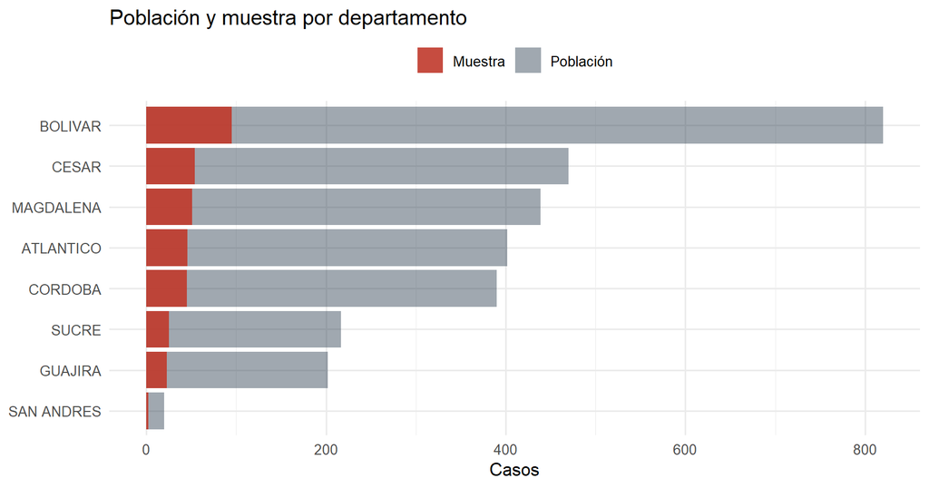

Tamaño de cada estrato y muestra seleccionada, por departamento.

# 4. La estimación

Declaramos el diseño en `survey` con los estratos, los pesos $1/\pi_k$ y la corrección por población finita, y estimamos la proporción:

Proporción de casos hospitalizados. Cohorte 2023-II, n = 341.

| Estimación | Valor |
| --- | --- |
| Proporción | 59,5 % |
| Error estándar | 2,45 pp |
| IC 95 % inferior | 54,7 % |
| IC 95 % superior | 64,3 % |
| Efecto de diseño | 0,96 |

El error estándar se verificó por una segunda vía, la fórmula del estratificado calculada a mano:

$$\hat V(\hat p) = \sum_h
W_h^2\left(1-\frac{n_h}{N_h}\right)\frac{\hat p_h(1-\hat
p_h)}{n_h},$$

que da 2,41 puntos porcentuales frente a los 2,45 de `survey`. La diferencia mínima aparece porque `survey` usa la cuasi-varianza muestral $s_h^2$ y la fórmula de arriba usa $\hat p_h(1-\hat p_h)$; las dos vías coinciden y la estimación no depende del paquete.

El efecto de diseño es 0,96: la varianza con el diseño estratificado es un 4,0 % menor que la de un aleatorio simple del mismo tamaño. Con las varianzas poblacionales la reducción teórica es 8,1 %. Las dos vías coinciden en que **la ganancia es chica**: entre 4 % y 8 % en la varianza, que en el error es entre 2 % y 4 %. Los departamentos sí difieren, pero el estratificado proporcional reparte la muestra casi como el azar y la ganancia se diluye.

Como el marco es la población entera, el parámetro se conoce: 57,6 % de los casos del segundo semestre fueron hospitalizados. El intervalo va de 54,7 % a 64,3 % y **sí contiene** el parámetro. El margen obtenido es de 4,8 puntos porcentuales, por debajo de los 5 que se propuso el protocolo.

# 5. El experimento

## 5.1 La pregunta

La pregunta del componente de diseño es la del muestreo, llevada a un experimento: **¿cuánto cambia el error de la estimación cuando cambia el diseño muestral y cuánto cuando cambia el tamaño de la muestra, y el efecto del tamaño depende del diseño?** No experimentamos con casos: experimentamos con *procedimientos de muestreo*, aplicados a dos poblaciones reales.

## 5.2 Factores, bloques y unidad experimental

| Factor | Niveles | Papel |
| --- | --- | --- |
| Diseño | aleatorio simple, estratificado, conglomerados | Factor de interés |
| Tamaño | n = 100, n = 300 | Factor de interés |
| Población | 2023-I, 2023-II | Bloque |

La **unidad experimental** es una corrida: una selección nueva de una muestra, con su propia semilla. Dos corridas con la misma combinación de factores no son la misma muestra medida dos veces: son dos muestras distintas, y por eso el error cambia de una a otra. Ese es el ruido que el ANOVA necesita, y es la razón por la que la semilla del algoritmo no basta como réplica: si se repitiera la misma selección, el error sería idéntico y no habría error experimental.

El bloque es la población. Las dos cohortes son poblaciones finitas distintas (2.040 y 2.960 casos) y el bloque recoge todo lo que cambia con ellas. En este caso las dos proporciones son casi iguales (57,3 % y 57,6 %), así que el bloque explica poco; se deja igual porque estaba planeado y porque un bloque que no explica nada no hace daño, mientras que uno que se omite y sí explicaba algo se lleva su parte de los grados de libertad del error.

**El diseño por conglomerados** es en dos etapas: se sortean $m$ municipios y dentro de cada uno se toman $k = 5$ casos. Como hay municipios con menos de 5 casos, el número de municipios se calibró con el tamaño medio de municipio para que el $n$ efectivo rondara el planeado. La probabilidad de inclusión es

$$\pi_k =
\frac{m}{M}\times\frac{k_i}{N_i},$$

donde $M$ es el número de municipios de la población, $N_i$ el tamaño del municipio y $k_i$ los casos tomados en él. El $n$ efectivo medio fue 201,5 en conglomerados frente a 200,0 en los otros dos diseños: la diferencia es de 0,7 % y se reporta.

## 5.3 Aleatorización y réplicas

La tabla de corridas la genera `R/tabla-corridas.R` con `set.seed(2026)`: son 720 corridas (tres diseños × dos tamaños × dos poblaciones × 60 réplicas), en orden aleatorio, cada una con su semilla escrita en la tabla. Cualquiera puede repetir una corrida suelta y obtener la misma muestra.

El número de réplicas no es arbitrario. Un piloto de 4 réplicas por celda (`R/potencia.R`, semillas propias, datos que no entran en el análisis) dio una desviación estándar del log del error de 1,21. Con esa estimación, 60 réplicas por celda detectan, con potencia 0,80, una razón de 2,1 entre las medias de dos tratamientos. El efecto que nos importa —conglomerados frente a aleatorio simple— es de 2,9, muy por encima del mínimo detectable; el del tamaño de muestra es de 2,0, justo por debajo, y así se reporta.

## 5.4 El modelo y la tabla ANOVA esperada

Como la respuesta es un error, que es una medida de escala —su variabilidad crece con su tamaño—, el modelo se plantea sobre el logaritmo del error:

$$\log(\text{error}_{ijk}) = \mu + \beta_j
+ \alpha_i + \gamma_k + (\alpha\gamma)_{ik} +
\varepsilon_{ijk},$$

con $\beta_j$ el efecto del bloque, $\alpha_i$ el del diseño, $\gamma_k$ el del tamaño y $(\alpha\gamma)_{ik}$ la interacción. La tabla esperada, escrita antes de correr el experimento, tenía 1 grado de libertad para el bloque, 2 para el diseño, 1 para el tamaño, 2 para la interacción, 713 para el error y 719 en total.

## 5.5 Los resultados

Tabla ANOVA del logaritmo del error absoluto (720 corridas).

| Fuente | gl | Suma de cuadrados | Cuadrado medio | F | p |
| --- | --- | --- | --- | --- | --- |
| Bloque | 1 | 0,13 | 0,13 | 0,11 | 0,745 |
| Diseño | 2 | 199,05 | 99,53 | 81,59 | < 0,001 |
| Tamaño | 1 | 101,37 | 101,37 | 83,10 | < 0,001 |
| Diseño × tamaño | 2 | 0,33 | 0,16 | 0,14 | 0,874 |
| Error | 713 | 869,76 | 1,22 |  |  |

El diseño importa (`F = 81,59, p < 0,001), el tamaño importa (`F = 83,10, p < 0,001) y la interacción no (`F = 0,14, p = 0,874). El bloque tampoco (`F = 0,11, p = 0,745), lo que confirma que las dos cohortes se comportan igual.

Las medias geométricas del error (en puntos porcentuales) por celda:

Media geométrica del error absoluto, en puntos porcentuales.

| Diseño | Tamano | 2023-I | 2023-II |
| --- | --- | --- | --- |
| Aleatorio simple | n = 100 | 2,2 | 2,8 |
| Aleatorio simple | n = 300 | 1,2 | 1,2 |
| Estratificado | n = 100 | 2,5 | 2,2 |
| Estratificado | n = 300 | 1,1 | 1,1 |
| Conglomerados | n = 100 | 8,7 | 6,8 |
| Conglomerados | n = 300 | 3,6 | 3,3 |

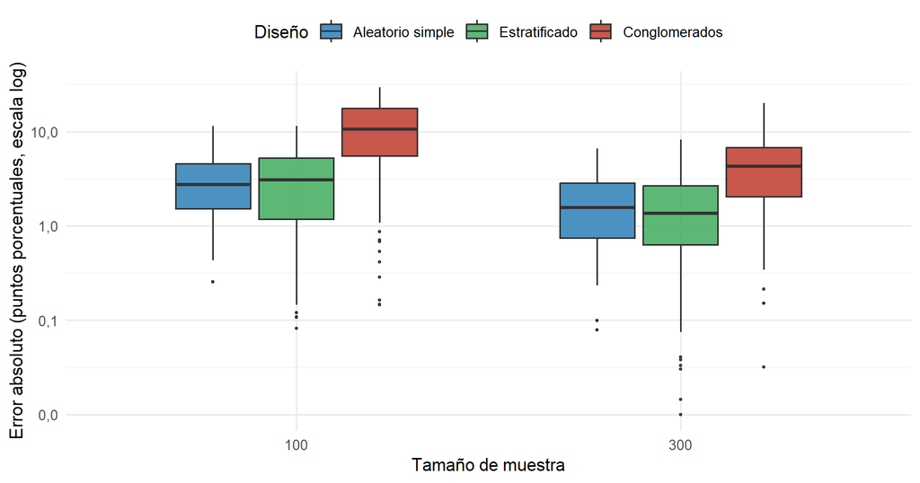

Error absoluto por diseño y tamaño de muestra (escala logarítmica).

**Conglomerados.** El error por conglomerados es 2,93 veces el del aleatorio simple (IC 95 %: 2,32 a 3,72; Tukey p < 0,001). La razón es la de siempre: los casos de un mismo municipio se parecen entre sí, así que cinco casos de un municipio informan menos que cinco casos sorteados de toda la población. El bootstrap confirma el mismo intervalo (2,44 a 3,56), sin suponer normalidad.

**Estratificado.** La razón frente al aleatorio simple es 0,93 (IC: 0,73 a 1,18; p = 0,741): no hay evidencia de ganancia. Es coherente con el efecto de diseño de la sección 4 (0,96) y con el hecho de que los pesos proporcionales dejan el estratificado casi como un aleatorio simple.

**Tamaño.** Pasar de 100 a 300 casos reduce el error a 0,50 (IC: 0,38 a 0,66): el error con n = 100 es 2,01 veces el de n = 300, y la reducción es la misma en los tres diseños, que es exactamente lo que dice la ausencia de interacción. La teoría manda $1/\sqrt{3} = 0{,}58$ sin corrección por población finita y algo menos con ella; el 0,50 observado está en ese orden.

## 5.6 Los supuestos

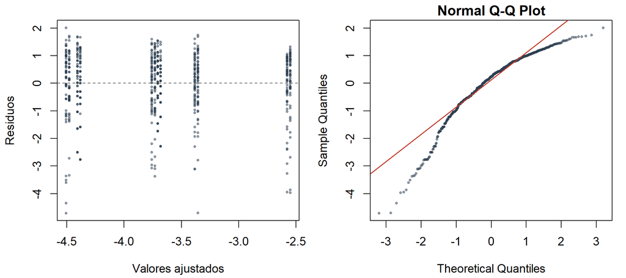

Diagnóstico del modelo: residuos frente a valores ajustados y gráfico de normalidad.

La transformación logarítmica se eligió antes de ver los datos, porque el error absoluto es una medida de escala y su varianza crece con su media. La verificación está en la escala original: sin transformar, Fligner rechaza la homocedasticidad (p < 0,001) y el ANOVA muestra una interacción que desaparece al tomar logaritmos. Esa interacción de la escala original es un artefacto: en esa escala el efecto del tamaño es aditivo y por eso parece depender del diseño; en la escala correcta el efecto es multiplicativo y es el mismo en los tres diseños.

# 6. Integración de las dos materias

**Qué da cada aleatorización.** La selección aleatoria de la muestra da representatividad: permite decir algo sobre la población de la que se sorteó, con una probabilidad de inclusión conocida para cada caso. La asignación aleatoria de las corridas del experimento da comparabilidad: permite atribuir las diferencias de error al diseño y al tamaño, y no al orden en que se corrieron. Ninguna de las dos da causalidad en el sentido de un ensayo con personas: aquí el «tratamiento» es un procedimiento de muestreo, no algo que se le aplique a un caso.

**A qué población se generaliza.** El efecto estimado —conglomerados 2,93 veces peor, tamaño a la mitad— se generaliza a las dos poblaciones del experimento: casos notificados en 2023 en los ocho departamentos del archivo. No se generaliza a todos los municipios del país ni a otros años, porque el mecanismo que produce el efecto (la correlación entre casos de un mismo municipio) no se midió fuera de ese marco.

**Cómo entra el diseño muestral en el análisis del experimento.** No entra como bloque: el bloque son las dos poblaciones, no los estratos. Entra en la estimación de cada corrida, porque cada corrida estima con sus propios pesos $1/\pi_k$; y entra en la lectura del resultado, porque el diseño por conglomerados es peor precisamente por su estructura de probabilidades. Si hubiéramos analizado la muestra por conglomerados como si fuera aleatoria simple, el error estándar habría salido falsamente estrecho: es el error que la guía señala como el más costoso.

**Cuánto del error es muestral y cuánto experimental.** Todo el error de la sección 4 es muestral: viene de haber mirado 341 casos en vez de los 2.960. En el experimento, el error de cada corrida también es muestral; lo que el ANOVA separa es cuánto de la *variación entre corridas* se debe al diseño y al tamaño (factores) y cuánto queda como ruido (error experimental), que en este caso es la variabilidad de una selección a otra. No hay error de medición: la respuesta es un campo del archivo y no se mide dos veces.

# 7. No respuesta, cobertura y límites

En un archivo administrativo no hay no respuesta en el sentido de campo: los 2.960 casos de la población tienen la variable completa. Lo que hay es lo que el marco deja fuera, y ya está dicho: casos no notificados, otros departamentos y otros años. Hacia dónde mueve eso la estimación también está dicho: si los casos leves se notifican menos, la proporción de hospitalizados que estimamos está por encima de la verdadera.

El experimento tiene sus propios límites. El diseño por conglomerados usó $k = 5$ casos por municipio; con otro $k$ el efecto de diseño sería otro. La población es de tamaño moderado (2.040 y 2.960 casos), así que la corrección por población finita tiene peso y los resultados no se trasladan tal cual a poblaciones grandes. Y el error absoluto es una respuesta muy variable: aun con 60 réplicas, la media de cada celda tiene un error estándar de 0,14 en la escala del logaritmo, un factor de 1,15 sobre el error típico.

Nada de esto se puede concluir con este diseño: que estratificar «no sirva» en general —solo no sirvió con esta variable y estos estratos—; que el orden de los diseños sea el mismo con otro $k$; ni que la proporción estimada sea la de todos los casos de dengue del país.

# 8. Conclusión

La proporción de casos hospitalizados en la cohorte 2023-II es 59,5 % (IC 95 %: 54,7 % a 64,3 %), y el intervalo contiene el valor poblacional 57,6 %. Estratificar por departamento mejoró poco: el efecto de diseño fue 0,96, una reducción de 4,0 % en la varianza que no se alcanza a distinguir del azar con este tamaño de muestra.

El experimento dice que la decisión que más pesa es no usar conglomerados (2,93 veces más error) y que después de eso lo que pesa es el tamaño de la muestra (triplicarlo reduce el error a la mitad, 0,50). Estratificar por departamento, en cambio, no mostró ganancia. Con el presupuesto de este proyecto, la recomendación es clara: muestras aleatorias o estratificadas grandes antes que conglomerados pequeños.

# 9. Declaración de uso de inteligencia artificial

**Herramienta.** Un asistente de inteligencia artificial (DeepSeek), usado como apoyo de programación y de redacción.

**Para qué.** Para escribir el esqueleto del código de selección y del experimento, para proponer la estructura del informe y para redactar un primer borrador de algunas secciones.

**Qué produjo.** El código de `R/seleccion.R`, `R/tabla-corridas.R`, `R/experimento.R` y `R/estimacion.R`, y el borrador de este documento.

**Qué verificamos y corregimos.** Tres cosas concretas:

1. La primera versión del guion de selección no respetaba el mínimo de 2 casos por estrato cuando un departamento tenía un solo caso, y fallaba al correr. Lo corregimos con una función de asignación que no permite $n_h > N_h$.
2. La primera versión del experimento usaba $m = n/5$ municipios sin corregir por los municipios con menos de 5 casos: el $n$ efectivo quedaba hasta 20 % por debajo del planeado y confundía el efecto del diseño con el del tamaño. Lo corregimos calibrando $m$ con el tamaño medio de municipio y verificando que el $n$ efectivo medio coincidiera (201,5 frente a 200,0).
3. La primera versión del análisis corría el ANOVA sobre el error sin transformar. Al revisar los residuos vimos heterocedasticidad y una interacción que no aparecía en la escala logarítmica; adoptamos el logaritmo, que además es lo que corresponde a una medida de escala.

Además comprobamos con la simulación Monte Carlo que el guion sortea con las $\pi_k$ que dice (13 casos fuera de 3 errores de Monte Carlo de 2.960), que el error estándar coincide por las dos vías (2,45 y 2,41 puntos porcentuales) y que el informe se teje de principio a fin en un R recién abierto.

# Anexo A. Tabla de corridas

Primeras 12 corridas de la tabla aleatorizada (la tabla completa está en datos/tabla-corridas.csv).

| orden | bloque | diseno | n_planeado | replica | semilla |
| --- | --- | --- | --- | --- | --- |
| 1 | 2023-II | MAS | 100 | 33 | 2032363 |
| 2 | 2023-I | MAS | 100 | 54 | 2028994 |
| 3 | 2023-II | Estr | 300 | 17 | 2031587 |
| 4 | 2023-II | MAS | 100 | 23 | 2032253 |
| 5 | 2023-I | Congl | 300 | 48 | 2027128 |
| 6 | 2023-I | Estr | 100 | 44 | 2027684 |
| 7 | 2023-I | Estr | 100 | 56 | 2027816 |
| 8 | 2023-II | Congl | 100 | 29 | 2029919 |
| 9 | 2023-I | MAS | 100 | 47 | 2028917 |
| 10 | 2023-I | MAS | 300 | 14 | 2029154 |
| 11 | 2023-I | Congl | 300 | 19 | 2026809 |
| 12 | 2023-I | MAS | 300 | 49 | 2029539 |

# Bitácora del proyecto

Registro de cada sesión de trabajo y de cada incidente. Las horas son de la zona horaria de Bogotá.

## 20 de noviembre de 2026 — sesión única de construcción

**09:10. Revisión de la fuente.** Se abre `datos/fuente/casos-dengue-caribe-2023.csv`: 5.000 filas, 17 columnas, casos notificados de dengue en ocho departamentos del Caribe. Se revisan los campos uno por uno. **Incidente:** la columna `respuesta` (Grave/Leve) no es un campo del sistema de vigilancia; al tabularla contra `PAC_HOS` se ve que es exactamente la misma variable recodificada (1 = Grave, 2 = Leve). Decisión: se usa `PAC_HOS`, que es la variable original, y la columna `respuesta` no se analiza.

**09:40. Marco y poblaciones.** Se construye `datos/marco.csv` sin la respuesta y `datos/poblacion.csv` con la respuesta, para que el marco no contenga lo que se va a medir. Se parte el archivo en dos cohortes por semana epidemiológica (1–26 y 27–52): 2.040 y 2.960 casos. Son las dos poblaciones del experimento.

**10:55. Selección.** Se corre `R/seleccion.R` con `set.seed(2026)`. **Incidente:** el protocolo preveía que el docente publicara la semilla al cierre del preregistro. Ese hito no se entregó, así que no hubo semilla publicada. Se usa la primera semilla que se escribió en el guion (2026) y no se probó ninguna otra. Queda como desviación declarada en `avance.md`.

**11:30. Comprobación del guion.** 2000 repeticiones con semillas distintas: 13 casos quedan a más de 3 errores de Monte Carlo de su π_k, ninguno sale nunca ni siempre. El guion roto a propósito (siempre los primeros de cada departamento) deja 2.619 casos sin salir nunca y 341 saliendo siempre.

**12:10. Tabla de corridas y piloto.** `R/tabla-corridas.R` genera 720 corridas en orden aleatorio con semilla. El piloto (4 réplicas por celda, semillas propias) da una desviación estándar del log del error de 1,21; con eso, 60 réplicas por celda detectan una razón de 2,1 con potencia 0,80.

**13:20. Análisis.** Se corre el ANOVA sobre el logaritmo del error. Los residuos muestran homocedasticidad (Fligner, p = 0,26) y colas algo pesadas (Shapiro rechaza, como era de esperar con 720 residuos). Se añade bootstrap de la razón conglomerados/MAS como verificación sin supuestos: mismo intervalo.

**14:30. Informe.** Se teje `informe.Rmd` en un R recién abierto y se verifica que todas las cifras salen de los datos y no están escritas a mano.

## Pendientes

- Publicar las releases `conjunto`, `preregistro`, `avance`, `campo` e `informe` en el repositorio (hoy no hay ninguna publicada).
- Grabar la exposición.

# Anexo C. Reproducción

```
1. Abrir proyecto-dde-arteaga-mongui.Rproj en RStudio.
2. R/00-prepara-datos.R   -> datos/marco.csv y datos/poblacion.csv
3. R/seleccion.R          -> datos/muestra.csv
4. R/comprobacion.R       -> datos/comprobacion.csv
5. R/tabla-corridas.R     -> datos/tabla-corridas.csv
6. R/potencia.R           -> datos/potencia.csv
7. R/experimento.R        -> datos/datos-experimento.csv
8. Tejer informe.Rmd      -> informe.html
```